# Practical Session 4 Adagrad-RMSProp-Adam Alaa

## Practical Work 4

For this practical work, the student will have to develop a Python program that is able to implement the accelerated gradient descent methods with adaptive learning rate **(Adagrad, RMSProp, and Adam)** in order to achieve the linear regression of a set of datapoints.

#### Import numpy, matplotlib.pyplot and make it inline

```python
import numpy as np
import matplotlib.pyplot as plt
import pandas as pd
from sklearn.metrics import r2_score
```

```python
x = np.linspace(0,20)
y =-2*x+1
```

```python
dict={'x':x , 'y':y}
df=pd.DataFrame(dict)
df.head()
```

|  | x | y |
| --- | --- | --- |
| 0 | 0.000000 | 1.000000 |
| 1 | 0.408163 | 0.183673 |
| 2 | 0.816327 | -0.632653 |
| 3 | 1.224490 | -1.448980 |
| 4 | 1.632653 | -2.265306 |

#### Plot your data points.

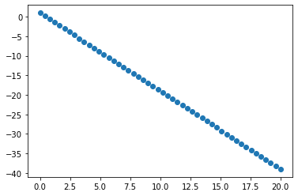

```python
plt.scatter(df.x,df.y)
```

```python
x=np.array(df.loc[:,['x']])
y=np.array(df.loc[:,['y']])
```

## Adagrad/

### For a single variable linear regression ML model, build a function to find the optimum Theta_0 and Theta_1 parameters using Adagrad optimization algorithm.

#### Try different values of the huperparameters and see the differnce in your results.

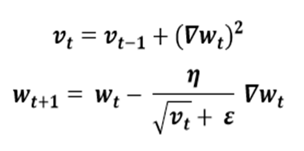

```python
alpha = 0.001
itera = 100
theta0=0
theta1=0
import sys
sys.float_info.epsilon
```

```
2.220446049250313e-16
```

```python
def Adagrad(x,y,alpha,epochs):
    theta_0=[]
    theta_1=[]
    ress=[]
    theta0=0
    theta1=0
    hyp=[]
    v0=0
    v1=0
    v_0=[]
    v_1=[]



    for i in range(epochs):
        h=theta0+theta1*x
        hyp.append(h)
        error = sum((h-y)**2)
        res = error/ (2 * len(x))
        ress.append(res)
        a = sum(h-y) / ( len(x))
        b = sum((h-y)*x) / ( len(x))

        v0=v0+ (a**2)
        v_0.append(v0)

        theta0 = theta0 - (alpha/(v0**(1/2))+(sys.float_info.epsilon))*a
        theta_0.append(theta0)

        v1=v1+ (b**2)
        v_1.append(v1)

        theta1 = theta1 - (alpha/(v1**(1/2))+(sys.float_info.epsilon))*b
        theta_1.append(theta1)

    dict1={"theta_0":theta0,"theta_1":theta1,"losses":ress,"hypothesis output":hyp,"optimum theta_0":theta_0,"optimum theta_1":theta_1}
    return dict1
```

```python
dict1=Adagrad(x,y,0.5,100)
```

```python
h=theta0+theta1*x
```

```python
from sklearn.metrics import r2_score
r2_score(y, dict1["hypothesis output"][-1] )
```

```
0.9933304101070646
```

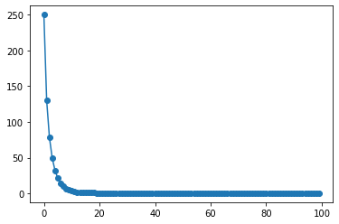

```python
plt.plot(dict1['losses'],'-o')
```

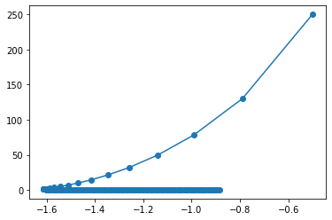

```python
plt.plot(dict1['optimum theta_0'],dict1['losses'],'-o')
```

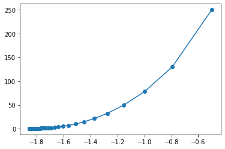

```python
plt.plot(dict1['optimum theta_1'],dict1['losses'],'-o')
```

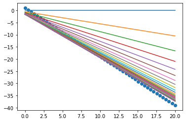

```python
plt.scatter(x,y)
for i in range(25) :
    plt.plot(x,dict1['hypothesis output'][i])
```

## RMSProp

### Update the previos implementation to be RMSProp.

#### Compare your results with Adagrad results.

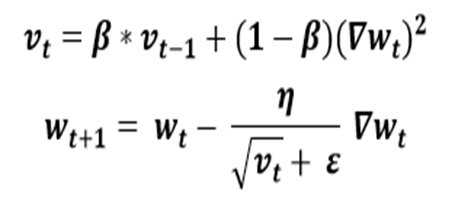

```python
def RMSProp(x,y,alpha,beta,epochs):
    theta_0=[]
    theta_1=[]
    ress=[]
    theta0=0
    theta1=0
    hyp=[]
    v0=0
    v1=0
    v_0=[]
    v_1=[]
    beta

    for i in range(epochs):
        h=theta0+theta1*x
        hyp.append(h)
        error = sum((h-y)**2)
        res = error/ (2 * len(x))
        ress.append(res)
        a = sum(h-y) / ( len(x))
        b = sum((h-y)*x) / ( len(x))


        v0=((beta*v0)+ ((1-beta)*(a**2)))
        v_0.append(v0)

        theta0 = theta0 - (alpha/(v0**(1/2))+(sys.float_info.epsilon))*a
        theta_0.append(theta0)

        v1=beta*v1+ ((1-beta)*(b**2))
        v_1.append(v1)

        theta1 = theta1 - (alpha/(v1**(1/2))+(sys.float_info.epsilon))*b
        theta_1.append(theta1)


    dict1={"theta_0":theta0,"theta_1":theta1,"losses":ress,"hypothesis output":hyp,"optimum theta_0":theta_0,"optimum theta_1":theta_1}
    return dict1
```

```python
dict2=RMSProp(x,y,0.5,0.002,1000)
```

```python
h=theta0+theta1*x
```

```python
from sklearn.metrics import r2_score
r2_score(y, dict2["hypothesis output"][-1] )
```

```
0.9198078472908228
```

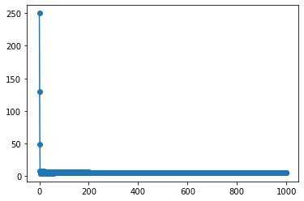

```python
plt.plot(dict2['losses'],'-o')
```

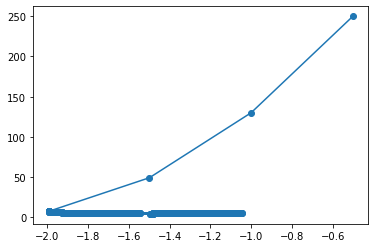

```python
plt.plot(dict2['optimum theta_0'],dict2['losses'],'-o')
```

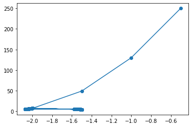

```python
plt.plot(dict2['optimum theta_1'],dict2['losses'],'-o')
```

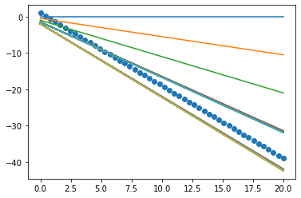

```python
plt.scatter(x,y)
for i in range(100) :
    plt.plot(x,dict2['hypothesis output'][i])
```

## Adam

### Update the previos implementation to be Adam.

#### Compare your results with Adagrad and RMSProp results.

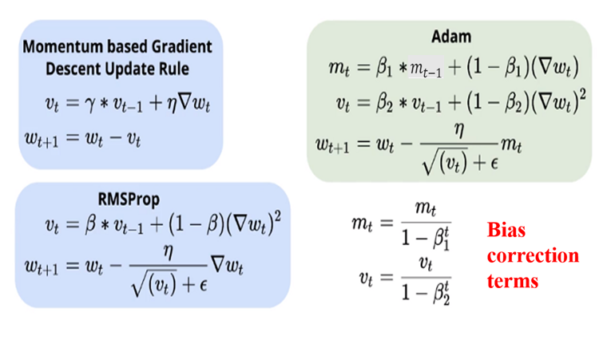

```python
def Adam(x,y,alpha,beta,epochs):
    theta_0=[]
    theta_1=[]
    ress=[]
    theta0=0
    theta1=0
    hyp=[]
    v0=0
    v1=0
    v_0=[]
    v_1=[]
    m0=0
    m1=0
    m_0=[]
    m_1=[]

    for i in range(epochs):
        h=theta0+theta1*x
        hyp.append(h)
        error = sum((h-y)**2)
        res = error/ (2 * len(x))
        ress.append(res)
        a = sum(h-y) / ( len(x))
        b = sum((h-y)*x) / ( len(x))

        m0=((beta*m0)+ ((1-beta)*(a)))
        m_0.append(m0)

        v0=((beta*v0)+ ((1-beta)*(a**2)))
        v_0.append(v0)

        theta0 = theta0 - (alpha/(v0**(1/2))+(sys.float_info.epsilon))*m0
        theta_0.append(theta0)

        m1=((beta*m1)+ ((1-beta)*(a)))
        m_1.append(m1)

        v1=beta*v1+ ((1-beta)*(b**2))
        v_1.append(v1)

        theta1 = theta1 - (alpha/(v1**(1/2))+(sys.float_info.epsilon))*m1
        theta_1.append(theta1)


    dict1={"theta_0":theta0,"theta_1":theta1,"losses":ress,"hypothesis output":hyp,"optimum theta_0":theta_0,"optimum theta_1":theta_1,"m0":m0,"m1":m1,"m_0":m_0,"m_1":m_1}
    return dict1
```

```python
dict3=Adam(x,y,.01,0.002,10000)
```

```python
from sklearn.metrics import r2_score
r2_score(y, dict3["hypothesis output"][-1] )
```

```
0.5556777550155737
```

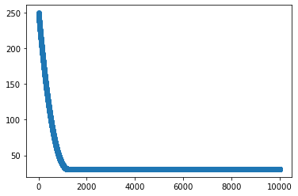

```python
plt.plot(dict3['losses'],'-o')
```

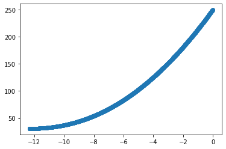

```python
plt.plot(dict3['optimum theta_0'],dict3['losses'],'-o')
```

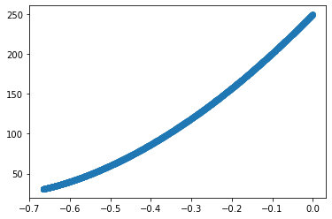

```python
plt.plot(dict3['optimum theta_1'],dict3['losses'],'-o')
```

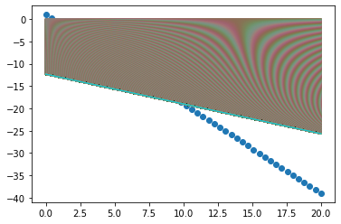

```python
plt.scatter(x,y)
for i in range(10000) :
    plt.plot(x,dict3['hypothesis output'][i])
```

## Congratulations

[figure not shown]